# Stroke Prediction

This notebook analyses Stroke Prediction dataset downloaded from [Kaggle](https://www.kaggle.com/datasets/fedesoriano/stroke-prediction-dataset).

This dataset is utilized for predicting the likelihood of a patient experiencing a stroke, considering input factors such as gender, age, different health conditions, and smoking habits. Each entry in the dataset contains relevant details about an individual patient.

## Goal

The goal of this project is to create a model that identifies individuals with high risk of getting a stroke.

## Objectives

To achieve this goal, the following objectives have been established:

1. Download, load and clean the dataset.
2. Conduct exploratory data analysis and visualize data to identify underlying patterns.
3. Perform statistical inference to validate findings.
4. Apply linear machine learning models to predict the likelihood of stroke occurrence.
5. Summarize the results and provide recommendations.

## Libraries

```python
import matplotlib.pyplot as plt
import numpy as np
import pandas as pd
import scipy.stats as stats
import seaborn as sns
import warnings
from IPython.core.display import HTML
from IPython.display import HTML
from imblearn.over_sampling import SMOTE
from imblearn.pipeline import Pipeline as ImbPipeline
from itertools import combinations
from joblib import dump
from scipy.stats import chi2_contingency, pointbiserialr, uniform, randint, spearmanr
from sklearn.compose import ColumnTransformer
from sklearn.dummy import DummyClassifier
from sklearn.ensemble import RandomForestClassifier
from sklearn.impute import SimpleImputer
from sklearn.inspection import permutation_importance
from sklearn.linear_model import LogisticRegression
from sklearn.metrics import (
    accuracy_score,
    classification_report,
    confusion_matrix,
    f1_score,
    precision_score,
    recall_score,
    roc_auc_score,
    roc_curve,
    precision_recall_curve,
    RocCurveDisplay,
    auc,
)
from sklearn.model_selection import (
    GridSearchCV,
    RandomizedSearchCV,
    StratifiedKFold,
    cross_val_score,
    train_test_split,
)
from sklearn.pipeline import Pipeline
from sklearn.preprocessing import (
    LabelEncoder,
    OneHotEncoder,
    StandardScaler,
    OrdinalEncoder,
)
from sklearn.svm import SVC
from sklearn.tree import DecisionTreeClassifier
from sklearn.metrics import roc_curve, RocCurveDisplay, auc, precision_recall_curve
import xgboost as xgb
from xgboost import XGBClassifier
```

```python
warnings.filterwarnings("ignore")

pd.set_option("display.float_format", lambda x: "%.3f" % x)

from IPython.core.display import HTML
HTML("""
<style>
.output_png {
    display: table-cell;
    text-align: center;
    vertical-align: middle;
}
</style>
""")
```

```python
plt.rcParams.update(
    {
        "font.family": "Lucida Sans",
        "axes.titlesize": 11,
        "axes.titlepad": 15,
    }
)

custom_palette = [
    "#ADD9F4",
    "#476C9B",
    "#4B644A",
    "#F4D06F",
    "#FF8811",
    "#07A0C3",
    "#B6465F",
    "#071E22",
    "#19323C",
    "#B1B695",
]
```

## Dataset

```python
df = pd.read_csv(
    r"C:\Users\nacev\OneDrive\healthcare-dataset-stroke-data.csv", index_col=0
)
```

```python
df.head()
```

| id | gender | age | hypertension | heart_disease | ever_married | work_type | Residence_type | avg_glucose_level | bmi | smoking_status | stroke |
| --- | --- | --- | --- | --- | --- | --- | --- | --- | --- | --- | --- |
| 9046 | Male | 67.000 | 0 | 1 | Yes | Private | Urban | 228.690 | 36.600 | formerly smoked | 1 |
| 51676 | Female | 61.000 | 0 | 0 | Yes | Self-employed | Rural | 202.210 | NaN | never smoked | 1 |
| 31112 | Male | 80.000 | 0 | 1 | Yes | Private | Rural | 105.920 | 32.500 | never smoked | 1 |
| 60182 | Female | 49.000 | 0 | 0 | Yes | Private | Urban | 171.230 | 34.400 | smokes | 1 |
| 1665 | Female | 79.000 | 1 | 0 | Yes | Self-employed | Rural | 174.120 | 24.000 | never smoked | 1 |

```python
df.info()
```

```
<class 'pandas.core.frame.DataFrame'>
Int64Index: 5110 entries, 9046 to 44679
Data columns (total 11 columns):
 #   Column             Non-Null Count  Dtype
---  ------             --------------  -----
 0   gender             5110 non-null   object
 1   age                5110 non-null   float64
 2   hypertension       5110 non-null   int64
 3   heart_disease      5110 non-null   int64
 4   ever_married       5110 non-null   object
 5   work_type          5110 non-null   object
 6   Residence_type     5110 non-null   object
 7   avg_glucose_level  5110 non-null   float64
 8   bmi                4909 non-null   float64
 9   smoking_status     5110 non-null   object
 10  stroke             5110 non-null   int64
dtypes: float64(3), int64(3), object(5)
memory usage: 479.1+ KB
```

The dataset comprises information about 5110 individuals and includes 11 features:

**gender** - patient's gender

**age** - patient's age

**hypertension** - information about whether the patient has hypertension

**heart_disease** - information about whether the patient has a heart disease

**ever_married** - information about whether the patient was ever married or not

**work_type** - information about the patient's working situation

**Residence_type** - information about the patient's current residence

**avg_glucose_level** - information about the patient's average glucose level in the blood

**bmi** - patient's body mass index measurement

**smoking_status** - information about the patient's smoking habits*

**stroke** - dependent variable containing information about whether the patient had a stroke or not

**Note: "Unknown" in smoking_status means that the information is unavailable for this patient*

```python
for column in df.columns:
    num_unique = df[column].nunique()
    print(f"Number of unique values in {column}: {num_unique}")
```

```
Number of unique values in gender: 3
Number of unique values in age: 104
Number of unique values in hypertension: 2
Number of unique values in heart_disease: 2
Number of unique values in ever_married: 2
Number of unique values in work_type: 5
Number of unique values in Residence_type: 2
Number of unique values in avg_glucose_level: 3979
Number of unique values in bmi: 418
Number of unique values in smoking_status: 4
Number of unique values in stroke: 2
```

Note that variable **gender** has 3 unique values; therefore, it will be investigated further.

```python
df.isna().sum()
```

```
gender                 0
age                    0
hypertension           0
heart_disease          0
ever_married           0
work_type              0
Residence_type         0
avg_glucose_level      0
bmi                  201
smoking_status         0
stroke                 0
dtype: int64
```

The dataset only has missing values in the **bmi** column, which will be dealt with later.

```python
duplicates = df[df.duplicated()]
num_duplicates = duplicates.shape[0]

print("Number of duplicate rows:", num_duplicates)
duplicates.head()
```

```
Number of duplicate rows: 0
```

|  | gender | age | hypertension | heart_disease | ever_married | work_type | Residence_type | avg_glucose_level | bmi | smoking_status | stroke |
| --- | --- | --- | --- | --- | --- | --- | --- | --- | --- | --- | --- |
| id |  |  |  |  |  |  |  |  |  |  |  |

The dataset does not contain duplicate entries.

## Exploratory Data Analysis

In this section the dataset is examined to gain insights and understand its characteristics.

### Overview

```python
numerical_features = ["age", "avg_glucose_level", "bmi"]

binary_features = [
    "hypertension",
    "heart_disease",
    "ever_married",
    "Residence_type",
    "stroke",
]
categorical_features = ["gender", "work_type", "smoking_status"]

df_encoded = df.replace({0: "No", 1: "Yes"})
```

```python
def create_countplot(
    df, ax, col, colors, plot_xlabel="", plot_ylabel="", percent=False
):
    """
    Creates a vertical countplot with the provided percentages on top.
    """
    counts = df[col].value_counts()
    bars = ax.bar(counts.index, counts.values, color=colors)

    ax.set_xlabel(plot_xlabel)
    ax.set_ylabel(plot_ylabel)
    ax.tick_params(axis="both", which="both", length=0)
    ax.spines["top"].set_visible(False)
    ax.spines["right"].set_visible(False)

    ax.grid(False)

    for spine in ax.spines.values():
        spine.set_color("black")

    if percent:
        total_height = counts.sum()
        for bar in bars:
            height = bar.get_height()
            ax.annotate(
                f"{height/total_height:.1%}",
                (bar.get_x() + bar.get_width() / 2, height),
                ha="center",
                va="bottom",
                fontsize=10,
                color="black",
                xytext=(0, 2),
                textcoords="offset points",
            )

    ax.set_title(ax.get_title(), y=0.5)
```

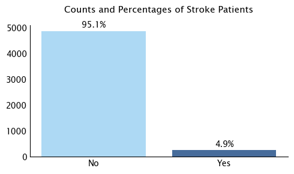

```python
fig, ax = plt.subplots(figsize=(5, 3))

col_to_plot = "stroke"

create_countplot(
    df=df_encoded,
    ax=ax,
    col=col_to_plot,
    colors=custom_palette,
    percent=1,
)

ax.set(title=f"Counts and Percentages of {col_to_plot.capitalize()} Patients")

plt.tight_layout()
plt.show()
```

The chart illustrates the distribution of patients based on their stroke status. Among the patients in the dataset, 95.1% did not have a stroke, while only 4.9% experienced a stroke.

This distribution indicates a significant class imbalance, with a vast majority of patients not having a stroke. This class imbalance can have implications for further analysis and modeling.

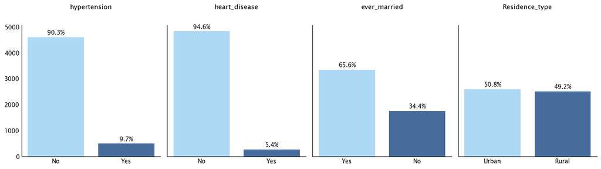

```python
fig, axes = plt.subplots(1, 4, figsize=(14, 4), sharey=True)

for i, col in enumerate(binary_features[:4]):
    create_countplot(
        df=df_encoded,
        ax=axes[i],
        col=col,
        colors=custom_palette,
        percent=1,
    )
    axes[i].set(title=f"{col}\n")

plt.tight_layout()
plt.show()
```

The results are also imbalanced in **hypertension** and **heart disease** columns - around 5% have the latter, while slightly more (10%) have the former.

More patients have been married (around 66%), meaning the sample is consisted of slightly older patients. Difference in residence type is almost non existent, 51% patients living in urban settlements and the rest in rural.

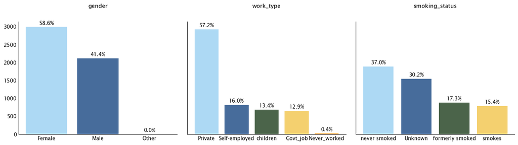

```python
fig, axes = plt.subplots(1, 3, figsize=(14, 4), sharey=True)

for i, col in enumerate(categorical_features):
    create_countplot(
        df=df_encoded,
        ax=axes[i],
        col=col,
        colors=custom_palette,
        percent=1,
    )
    axes[i].set(title=f"{col}\n")

plt.tight_layout()
plt.show()
```

Regarding the gender distribution, more patients are female (59%). There is one patient in 'other' category; this category will be removed later in the analysis.

More than half of the patients work in private sector (57%), others are self-employed (16%), work in government sector (13%) or are children/never worked before (14%).

Almost a third has their smoking status as unknown, while 37% of the patients have never smoked before. Another third are former smokers or current smokers.

```python
summary_stats = df[["age", "avg_glucose_level", "bmi"]].describe()
summary_stats
```

|  | age | avg_glucose_level | bmi |
| --- | --- | --- | --- |
| count | 5110.000 | 5110.000 | 4909.000 |
| mean | 43.227 | 106.148 | 28.893 |
| std | 22.613 | 45.284 | 7.854 |
| min | 0.080 | 55.120 | 10.300 |
| 25% | 25.000 | 77.245 | 23.500 |
| 50% | 45.000 | 91.885 | 28.100 |
| 75% | 61.000 | 114.090 | 33.100 |
| max | 82.000 | 271.740 | 97.600 |

The average age of individuals in the dataset is approximately 43 years, with a standard deviation of about 22.6 years, indicating a wide range of ages. The mean average glucose level is around 106 mg/dL, with a standard deviation of about 45.3 mg/dL. The mean BMI (Body Mass Index) is approximately 28.9, with a standard deviation of about 7.9.

The age data ranges from a minimum of 0.08 years (or about 1 month) to a maximum of 82 years, reflecting a broad age distribution. The average glucose level ranges from 55.12 mg/dL to 271.74 mg/dL, and the BMI values range from 10.3 to 97.6.

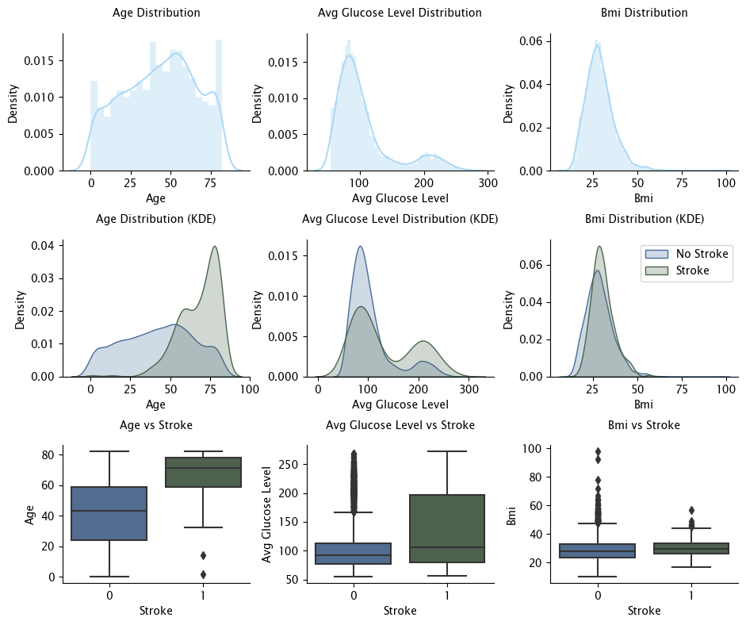

```python
plt.figure(figsize=(11, 9))
for i, col in enumerate(numerical_features, start=1):
    formatted_col = col.title().replace("_", " ")

    plt.subplot(3, 3, i)
    plt.title(f"{formatted_col} Distribution", fontsize=10)
    plt.xlabel(formatted_col)
    sns.distplot(x=df[col], color=custom_palette[0])

    plt.subplot(3, 3, i + 3)
    plt.title(f"{formatted_col} Distribution (KDE)", fontsize=10)
    plt.xlabel(formatted_col)
    sns.kdeplot(
        df[df["stroke"] == 0][col],
        fill=True,
        label="No Stroke",
        color=custom_palette[1],
    )
    sns.kdeplot(
        df[df["stroke"] == 1][col], fill=True, label="Stroke", color=custom_palette[2]
    )
    if i == 3:
        plt.legend()

    plt.subplot(3, 3, i + 6)
    plt.title(f"{formatted_col} vs Stroke", fontsize=10)
    sns.boxplot(x="stroke", y=col, data=df, palette=custom_palette[1:3])
    plt.xlabel("Stroke")
    plt.ylabel(formatted_col)

    sns.despine()

plt.subplots_adjust(hspace=0.5, wspace=0.3)
plt.show()
```

It can be observed that all three numerical features do not follow a normal distribution, with average glucose level and BMI features being right-skewed.

The distributions of BMI appear fairly similar between individuals who had a stroke and those who did not, with the average BMI being slightly higher among those who experienced a stroke. Similarly, glucose levels are quite similar between the groups, although higher values occur more frequently in the stroke group. The most significant differences are found in age distributions, with older people being more likely to have a stroke.

While boxplots suggest the presence of outliers, since all values are plausible within the context of all three features, they will be retained for further analysis.

```python
def create_stacked_barchart(
    df, ax, col_x, col_hue, colors, plot_xlabel="", plot_ylabel="", percent=False
):
    """
    Creates a stacked bar plot with the provided percentages on top.
    """
    counts = pd.crosstab(df[col_x], df[col_hue], normalize="index")
    bars = counts.plot(kind="bar", stacked=True, color=colors, ax=ax)

    ax.set_xlabel(plot_xlabel)
    ax.set_ylabel(plot_ylabel)
    ax.tick_params(axis="x", which="both", length=0)
    ax.spines["top"].set_visible(False)
    ax.spines["right"].set_visible(False)

    ax.grid(False)
    ax.legend_ = None

    for spine in ax.spines.values():
        spine.set_color("black")

    if percent:
        for bar in bars.patches:
            width, height = bar.get_width(), bar.get_height()
            x, y = bar.get_xy()
            ax.annotate(
                f"{height:.1%}",
                (x + width / 2, y + height / 2),
                ha="center",
                va="center",
                fontsize=10,
                color="black",
                xytext=(0, 2),
                textcoords="offset points",
            )

    ax.set_title(ax.get_title(), y=0.5)
```

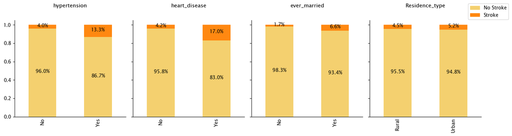

```python
fig, axes = plt.subplots(1, 4, figsize=(14, 4), sharey=True)

for i, col in enumerate(binary_features[:4]):
    create_stacked_barchart(
        df=df_encoded,
        ax=axes[i],
        col_x=col,
        col_hue="stroke",
        colors=custom_palette[3:],
        percent=True,
    )
    axes[i].set(title=f"{col}\n")

handles = [
    plt.Rectangle((0, 0), 1, 1, color=custom_palette[3]),
    plt.Rectangle((0, 0), 1, 1, color=custom_palette[4]),
]
labels = ["No Stroke", "Stroke"]

fig.legend(handles, labels, loc="upper right", bbox_to_anchor=(1.05, 0.98))

plt.tight_layout()
plt.show()
```

It is evident that the occurrence of strokes is higher among individuals with hypertension, heart disease, and those who have ever been married. While being married increased the occurrence by 5%, this could also be correlated with age, as older individuals have a higher chance of ever being married.

Significant differences are observed with hypertension, where the occurrence of stroke increases more than 3 times, from 4% to more than 13%. Similarly, for heart disease, 17% of people with heart disease experience a stroke, while only around 4% (approximately 4 times less) experience a stroke when no heart disease is present.

On the other hand, differences in stroke numbers between different residence types were minimal.

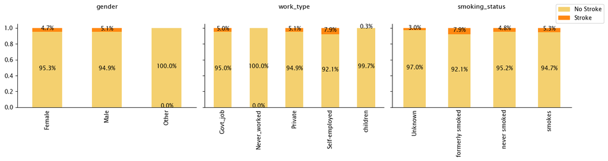

```python
fig, axes = plt.subplots(1, 3, figsize=(14, 4), sharey=True)

for i, col in enumerate(categorical_features):
    create_stacked_barchart(
        df=df_encoded,
        ax=axes[i],
        col_x=col,
        col_hue="stroke",
        colors=custom_palette[3:],
        percent=True,
    )
    axes[i].set(title=f"{col}\n")

handles = [
    plt.Rectangle((0, 0), 1, 1, color=custom_palette[3]),
    plt.Rectangle((0, 0), 1, 1, color=custom_palette[4]),
]
labels = ["No Stroke", "Stroke"]

fig.legend(handles, labels, loc="upper right", bbox_to_anchor=(1.05, 0.98))

plt.tight_layout()
plt.show()
```

Male patients are only slightly more likely to experience a stroke (5.1% versus 4.7%). Among different work types, self-employed individuals are most likely to experience a stroke (7.9%), although the differences are again minimal.

When considering smoking status, former smokers are at the highest risk of experiencing a stroke (7.9%), but only a few percentage points more often than non-smokers and current smokers.

### Correlations

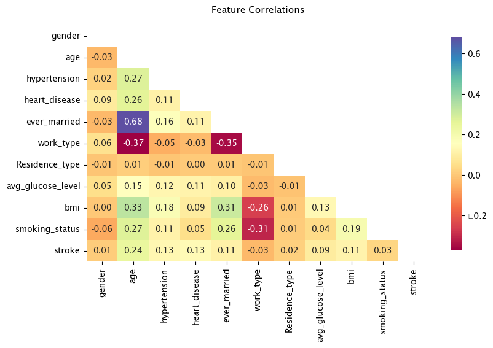

```python
label_encoder = LabelEncoder()
df_encoded = df.apply(label_encoder.fit_transform)

corr_matrix = df_encoded.corr()

mask = np.triu(np.ones_like(corr_matrix, dtype=bool))

plt.figure(figsize=(9, 5))

sns.heatmap(
    corr_matrix,
    mask=mask,
    annot=True,
    cmap="Spectral",
    fmt=".2f",
    cbar_kws={"shrink": 0.9},
)

plt.title("Feature Correlations")
plt.show()
```

Looking at the correlation between features, the strongest correlation quite obviously exists between the *ever_married* and *age* features, with being older increasing the possibility of ever being married.

*Work_type* has negative correlations with *age*, *ever_married*, *bmi* and *smoking_status*. Also, *age* is weakly positively correlated with *hypertension*, *heart_disease*, *bmi* and *smoking_status*. It also has strongest correlation (0.24) out of other features with the dependent variable *stroke*.

## Statistical Inference

Further, statistical inference will be performed.

### First Hypothesis

**Null Hypothesis (H0):** There is no significant correlation between categorical independent variables and the dependent variable.

**Alternative Hypothesis (H1):** There is a significant correlation between categorical independent variables and the dependent variable.

```python
df = df[df["gender"] != "Other"]
all_categorical = binary_features + categorical_features
```

```python
alpha = 0.05
num_comparisons = len(all_categorical) - 1
bonferroni_alpha = alpha / num_comparisons
bonferroni_alpha
```

```
0.0071428571428571435
```

The significance level is set to be 0.05. Since multiple comparisons are going to be made, the significance level needs to be adjusted to account for the increased chance of Type I errors due to multiple tests.

Therefore, each test would need to have a p-value less than 0.007 to be considered statistically significant.

```python
for col in all_categorical:
    if col != "stroke":
        contingency_table = pd.crosstab(df["stroke"], df[col])
        chi2, p_value, _, _ = chi2_contingency(contingency_table)

        n = contingency_table.sum().sum()
        phi2 = chi2 / n
        min_dim = min(contingency_table.shape) - 1
        cramer_v = np.sqrt(phi2 / min_dim)

        print(f"Variable: {col}")
        print(f"Chi-square statistic: {chi2:.3f}")
        print(f"P-value: {p_value:.3f}")
        print(f"Cramer's V: {cramer_v:.3f}")
        print("\n")
```

```
Variable: hypertension
Chi-square statistic: 81.573
P-value: 0.000
Cramer's V: 0.126


Variable: heart_disease
Chi-square statistic: 90.229
P-value: 0.000
Cramer's V: 0.133


Variable: ever_married
Chi-square statistic: 58.868
P-value: 0.000
Cramer's V: 0.107


Variable: Residence_type
Chi-square statistic: 1.075
P-value: 0.300
Cramer's V: 0.015


Variable: gender
Chi-square statistic: 0.340
P-value: 0.560
Cramer's V: 0.008


Variable: work_type
Chi-square statistic: 49.159
P-value: 0.000
Cramer's V: 0.098


Variable: smoking_status
Chi-square statistic: 29.226
P-value: 0.000
Cramer's V: 0.076
```

Work type and smoking status also displayed significant associations with strokes, although with moderate effect sizes. This indicates that these factors contribute to the likelihood of strokes but to a lesser extent compared to hypertension, heart disease, and marital status.

### Second Hypothesis

**Null Hypothesis (H0):** There is no difference in the distribution of age between individuals who have had a stroke and those who have not.

**Alternative Hypothesis (H1):** There is a difference in the distribution of age between individuals who have had a stroke and those who have not.

**Significance Level:** 0.05

```python
age_stroke = df[df["stroke"] == 1]["age"]
age_non_stroke = df[df["stroke"] == 0]["age"]

statistic, p_value = stats.mannwhitneyu(age_stroke, age_non_stroke)

print(f"Mann-Whitney U statistic: {statistic}")
print(f"P-value: {p_value:.3f}")

alpha = 0.05
if p_value < alpha:
    print(
        "Reject the null hypothesis: There is a significant difference in age distribution between stroke and non-stroke groups."
    )
else:
    print(
        "Fail to reject the null hypothesis: There is no significant difference in age distribution between stroke and non-stroke groups."
    )
```

```
Mann-Whitney U statistic: 1009878.5
P-value: 0.000
Reject the null hypothesis: There is a significant difference in age distribution between stroke and non-stroke groups.
```

In this case, a p-value of 0.000 (or very close to zero) indicates strong evidence against the null hypothesis, and we can conclude that there is a significant difference in age distribution between groups.

## Statistical Modeling

This section aims to build a model that could accurately predict which individuals are likely to experience stroke.

### Data Preparation

The data has been prepared for statistical modeling by partitioning it into training and testing sets. Additionally, the features have been scaled to ensure uniformity and facilitate accurate model training and evaluation.

#### Outliers

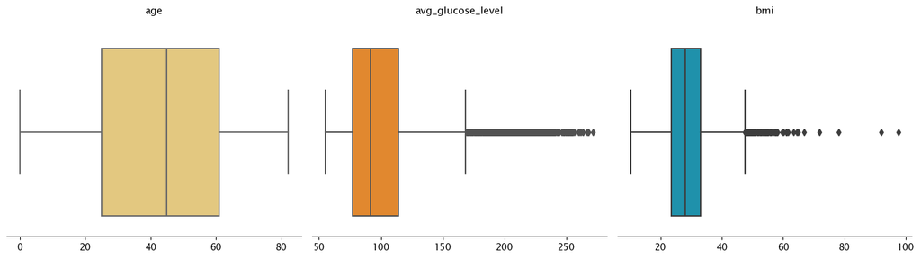

```python
fig, axes = plt.subplots(1, 3, figsize=(14, 4))

for i, col in enumerate(numerical_features):
    sns.boxplot(x=df[col], ax=axes[i], color=custom_palette[i + 3])
    sns.despine(ax=axes[i], left=True)

    axes[i].set_title(f"{col}")
    axes[i].set_xlabel("")
    axes[i].tick_params(axis="y", length=0)

plt.tight_layout()
plt.show()
```

Like mentioned before, apparent outliers are entirely possible to exist. Average glucose levels can go up to thousands, although values above 300 mg/dL [are already very dangerous](https://www.buzzrx.com/blog/how-are-dangerous-blood-sugar-levels-defined) but possible.

Also, even though BMI of more than 40 is already considered class III - highest class of obesity - values as high as 251 [were recorded](https://en.wikipedia.org/wiki/List_of_heaviest_people).

Therefore, the outliers are going to be kept. Wide range of values is going to be considered during feature engineering stage, as forming intervals might be beneficial.

#### Train-Test Split

```python
X = df.drop(["stroke"], axis=1)
y = df["stroke"]

(X_train, X_test, y_train, y_test) = train_test_split(
    X, y, test_size=0.2, random_state=1
)
```

The dataset is separated into train and test samples for further analysis.

#### Data Preprocessing Pipelines

```python
numerical_features = ["age", "avg_glucose_level", "bmi"]

binary_features = [
    "gender",
    "hypertension",
    "heart_disease",
    "ever_married",
    "Residence_type",
]

categorical_features = ["work_type", "smoking_status"]
```

```python
numeric_transformer = Pipeline(
    steps=[("imputer", SimpleImputer(strategy="median")), ("scaler", StandardScaler())]
)

binary_transformer = Pipeline(
    steps=[
        (
            "binary",
            OrdinalEncoder(handle_unknown="use_encoded_value", unknown_value=-1),
        ),
    ]
)

categorical_transformer = Pipeline(
    steps=[("categorical", OneHotEncoder(handle_unknown="ignore"))]
)
```

```python
preprocessor = ColumnTransformer(
    transformers=[
        ("numeric", numeric_transformer, numerical_features),
        ("binary", binary_transformer, binary_features),
        ("categorical", categorical_transformer, categorical_features),
    ]
)
```

After defining list of different types of features, a data preprocessing pipeline is developed to ensure that the data is appropriately preprocessed by handling missing values, scaling features, encoding categorical and binary variables.

```python
X_train_prep = preprocessor.fit_transform(X_train)

one_hot_feature_names = (
    preprocessor.transformers_[2][1]
    .named_steps["categorical"]
    .get_feature_names_out(categorical_features)
)

all_feature_names = numerical_features + binary_features + list(one_hot_feature_names)

X_train_prep_df = pd.DataFrame(X_train_prep, columns=all_feature_names)
X_train_prep_df.head()
```

|  | age | avg_glucose_level | bmi | gender | hypertension | heart_disease | ever_married | Residence_type | work_type_Govt_job | work_type_Never_worked | work_type_Private | work_type_Self-employed | work_type_children | smoking_status_Unknown | smoking_status_formerly smoked | smoking_status_never smoked | smoking_status_smokes |
| --- | --- | --- | --- | --- | --- | --- | --- | --- | --- | --- | --- | --- | --- | --- | --- | --- | --- |
| 0 | 1.591 | -0.738 | -0.679 | 1.000 | 1.000 | 0.000 | 1.000 | 1.000 | 0.000 | 0.000 | 0.000 | 1.000 | 0.000 | 0.000 | 1.000 | 0.000 | 0.000 |
| 1 | 1.369 | -0.824 | -0.194 | 0.000 | 0.000 | 0.000 | 1.000 | 1.000 | 0.000 | 0.000 | 0.000 | 1.000 | 0.000 | 0.000 | 1.000 | 0.000 | 0.000 |
| 2 | -0.405 | 1.529 | -0.758 | 0.000 | 0.000 | 0.000 | 1.000 | 0.000 | 0.000 | 0.000 | 1.000 | 0.000 | 0.000 | 0.000 | 0.000 | 1.000 | 0.000 |
| 3 | 1.636 | -1.072 | -0.272 | 1.000 | 0.000 | 0.000 | 1.000 | 0.000 | 0.000 | 0.000 | 1.000 | 0.000 | 0.000 | 0.000 | 0.000 | 1.000 | 0.000 |
| 4 | 0.260 | -0.446 | -0.443 | 0.000 | 0.000 | 0.000 | 1.000 | 0.000 | 0.000 | 0.000 | 1.000 | 0.000 | 0.000 | 1.000 | 0.000 | 0.000 | 0.000 |

Further, the data is fitted and transformed and original feature names are retrieved.

#### Oversampling

```python
smote = SMOTE(random_state=1)
X_train_resampled, y_train_resampled = smote.fit_resample(X_train_prep_df, y_train)
```

To address class imbalance, the Synthetic Minority Oversampling Technique (SMOTE) is used to perform oversampling on the training data.

The data is now ready to use for further analysis and model training.

### Model Training and Evaluation

#### Benchmark Classifier

```python
dummy_classifier = DummyClassifier(strategy="stratified", random_state=1)
dummy_classifier.fit(X_train, y_train)
y_pred_dummy = dummy_classifier.predict(X_test)

print("Classification Report for Dummy Classifier:")
print(classification_report(y_test, y_pred_dummy))
```

```
Classification Report for Dummy Classifier:
              precision    recall  f1-score   support

           0       0.94      0.96      0.95       962
           1       0.10      0.07      0.08        60

    accuracy                           0.91      1022
   macro avg       0.52      0.51      0.52      1022
weighted avg       0.89      0.91      0.90      1022
```

The benchmark classifier, implemented using the DummyClassifier with a "stratified" strategy, serves as a baseline model to evaluate the performance of more complex classifiers.

The results show a high accuracy of 91%. However, this accuracy is mainly attributed to correctly predicting the majority class (no stroke), with a precision of 94% and a recall of 96%. On the other hand, the classifier performs poorly in predicting the minority class (stroke), with a precision of only 10% and a recall of 7%. Consequently, the F1-score for the minority class is very low at 0.08, indicating poor performance in identifying instances of the minority class.

#### Model Selection

##### Hyperparameter Tuning

```python
results = []

classifiers = {
    "Logistic Regression": (
        LogisticRegression(random_state=1, max_iter=1000),
        {"C": [0.1, 1, 10], "penalty": ["l1", "l2"], "solver": ["liblinear"]},
    ),
    "Random Forest": (
        RandomForestClassifier(random_state=1),
        {
            "n_estimators": [10, 50, 100],
            "max_depth": [2, 5, 10],
            "bootstrap": [True, False],
        },
    ),
    "XGBoost": (
        XGBClassifier(random_state=1),
        {
            "n_estimators": [10, 50, 100],
            "learning_rate": [0.01, 0.05, 0.1],
            "max_depth": [3, 5, 7],
        },
    ),
    "Support Vector Classifier": (
        SVC(random_state=1, probability=True),
        {
            "C": [0.1, 1, 5],
            "kernel": ["linear", "rbf", "poly"],
            "gamma": ["scale", "auto"],
        },
    ),
}
```

```python
strat_kf = StratifiedKFold(n_splits=5, shuffle=True, random_state=1)

best_params = {}

for clf_name, (classifier, param_grid) in classifiers.items():
    print(f"Hyperparameter tuning for {clf_name}")

    grid_search = GridSearchCV(
        estimator=classifier,
        param_grid=param_grid,
        cv=strat_kf,
        scoring="recall",
    )
    grid_search.fit(X_train_resampled, y_train_resampled)

    best_params[clf_name] = grid_search.best_params_

    results.append(
        {
            "Model": clf_name,
            "Best Params": grid_search.best_params_,
            "Best Score": grid_search.best_score_,
            "Best Estimator": grid_search.best_estimator_,
        }
    )

for result in results:
    best_model = result["Best Estimator"]

    y_pred = best_model.predict(X_train_resampled)

    accuracy = accuracy_score(y_train_resampled, y_pred)
    precision = precision_score(y_train_resampled, y_pred)
    recall = recall_score(y_train_resampled, y_pred)
    f1 = f1_score(y_train_resampled, y_pred)
    rocauc = roc_auc_score(y_train_resampled, y_pred)

    result.update(
        {
            "Accuracy": accuracy,
            "Precision": precision,
            "Recall": recall,
            "F1": f1,
            "ROC AUC": rocauc,
        }
    )
```

```
Hyperparameter tuning for Logistic Regression
Hyperparameter tuning for Random Forest
Hyperparameter tuning for XGBoost
Hyperparameter tuning for Support Vector Classifier
```

In this case, the scoring metric chosen is recall. Since correctly identifying positive cases is crucial, the grid search prioritizes models that minimize false negatives.

```python
results_df = pd.DataFrame(results)
results_df.drop(["Best Params", "Best Estimator", "Best Score"], axis=1, inplace=True)
results_df
```

|  | Model | Accuracy | Precision | Recall | F1 | ROC AUC |
| --- | --- | --- | --- | --- | --- | --- |
| 0 | Logistic Regression | 0.780 | 0.756 | 0.825 | 0.789 | 0.780 |
| 1 | Random Forest | 0.955 | 0.934 | 0.979 | 0.956 | 0.955 |
| 2 | XGBoost | 0.989 | 0.987 | 0.991 | 0.989 | 0.989 |
| 3 | Support Vector Classifier | 0.944 | 0.911 | 0.986 | 0.947 | 0.944 |

In the model selection phase, several classifiers were trained and evaluated using the training dataset. Each classifier was trained on the scaled training data, and then evaluated based on various performance metrics, including accuracy, precision, recall, and F1-score.

**Logistic Regression:** While it has a relatively lower accuracy compared to other models, it maintains a reasonable balance between precision and recall.

**Random Forest:** Model exhibits high performance across all metrics, although its recall was not the highest out of all models.

**XGBoost:** Model demonstrates outstanding performance with a recall of 99.1%, which is the highest among all models.

**Support Vector Classifier (SVC):** Model also performed well across all metrics, especially in recall, and only had slightly lower metrics than those of XGBoost's.

Nonetheless, such high values could indicate potential issues such as overfitting, data leakage, or imbalanced dataset handling.

Considering the importance of recall in stroke detection and the need for interpretability, the Random Forest and Logistic Regression models are going to be chosen for further analysis. Despite its slightly lower accuracy compared to XGBoost, Random Forest model strikes an optimal balance between interpretability and performance. These two models are also relatively easier to interpret compared to XGBoost and SVC.

```python
best_params_logreg = best_params.get("Logistic Regression")
best_params_rf = best_params.get("Random Forest")
```

##### Feature Importance

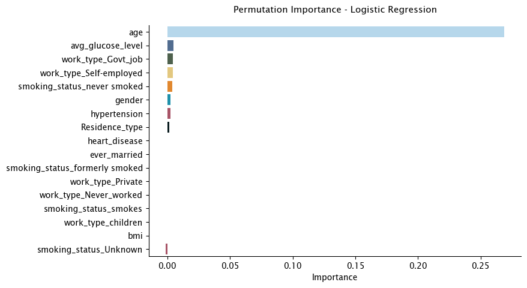

```python
logreg_model = LogisticRegression(**best_params_logreg, random_state=1)
logreg_model.fit(X_train_resampled, y_train_resampled)

perm_importance = permutation_importance(
    logreg_model, X_train_resampled, y_train_resampled, n_repeats=10, random_state=1
)

feature_names = X_train_resampled.columns

mean_perm_importance = perm_importance.importances_mean

sorted_indices = mean_perm_importance.argsort()[::-1]
sorted_feature_names = feature_names[sorted_indices]
sorted_importances = mean_perm_importance[sorted_indices]

plt.figure(figsize=(8, 5))
sns.barplot(x=sorted_importances, y=sorted_feature_names, palette=custom_palette)
plt.title("Permutation Importance - Logistic Regression")
plt.xlabel("Importance")
plt.ylabel("")
sns.despine()
plt.show()
```

Permutation importance is a technique used to assess the importance of features in a machine learning model by evaluating how much the model's performance deteriorates when the values of each feature are randomly shuffled.

Among the features examined, *age* appears to have by far the highest permutation importance, suggesting that changes in age significantly affect the model's predictions. Other notable features include *avg_glucose_level*, *work_type_Govt_job*, *work_type_Self-employed*, and *smoking_status_never smoked*.

Features with lower or negative permutation importance values may have less influence on the model's predictions or potentially even confuse the model when their values are permuted.

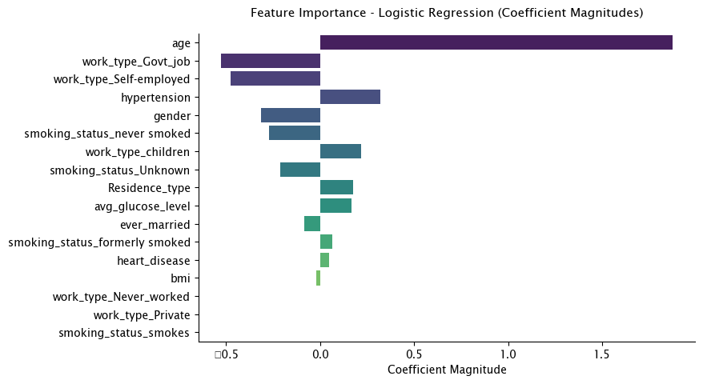

```python
coefficients = logreg_model.coef_[0]

coefficients_df = pd.DataFrame(
    {"Feature": X_train_resampled.columns, "Coefficient": coefficients}
)

coefficients_df = coefficients_df.reindex(
    coefficients_df["Coefficient"].abs().sort_values(ascending=False).index
)

plt.figure(figsize=(8, 5))
sns.barplot(x="Coefficient", y="Feature", data=coefficients_df, palette="viridis")
plt.title("Feature Importance - Logistic Regression (Coefficient Magnitudes)")
plt.xlabel("Coefficient Magnitude")
plt.ylabel("")
sns.despine()
plt.show()
```

Another way to look at feature importance is calculating the logistic regression coefficients, which reveal the impact of each feature on stroke prediction.

Age has the highest positive coefficient (1.873), indicating its strong association with stroke risk, while having a government job (-0.526) or being self-employed (-0.475) are negatively associated. Hypertension (0.321) also positively contributes to stroke prediction. Conversely, features such as gender (-0.316) and never smoked status (-0.274) have negative coefficients. Features like BMI (-0.019) and heart disease (0.048) have comparatively smaller coefficients, indicating less influence on stroke prediction.

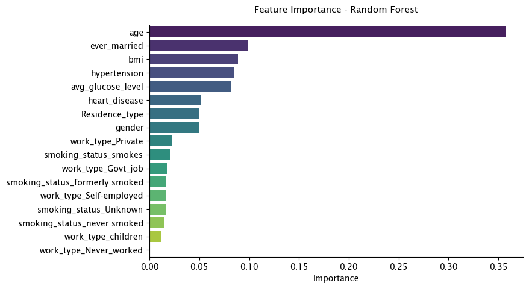

```python
rf_model = RandomForestClassifier(**best_params_rf, random_state=1)
rf_model.fit(X_train_resampled, y_train_resampled)

importances = rf_model.feature_importances_

feature_names = X_train_resampled.columns

sorted_indices = importances.argsort()[::-1]
sorted_feature_names = feature_names[sorted_indices]
sorted_importances = importances[sorted_indices]

plt.figure(figsize=(8, 5))
sns.barplot(x=sorted_importances, y=sorted_feature_names, palette="viridis")
plt.title("Feature Importance - Random Forest")
plt.xlabel("Importance")
plt.ylabel("")
sns.despine()
plt.show()
```

The feature importances obtained from the Random Forest classifier reveal that age, marital status (ever_married), and BMI are the most influential predictors of stroke occurrence. Other significant factors include hypertension, average glucose level, heart disease, and residence type. Employment status, smoking status, and gender also contribute to the model's predictions, albeit to a lesser extent.

However, there are discrepancies; for instance, *smoking_status_never smoked* feature shows importance in Logistic Regression but not in Random Forest. This suggests variations in how models interpret feature importance.

#### Model Evaluation

```python
X_test_prep = preprocessor.transform(X_test)

one_hot_feature_names = (
    preprocessor.transformers_[2][1]
    .named_steps["categorical"]
    .get_feature_names_out(categorical_features)
)

all_feature_names = numerical_features + binary_features + list(one_hot_feature_names)

X_test_prep_df = pd.DataFrame(X_test_prep, columns=all_feature_names)
```

```python
y_pred_logreg = logreg_model.predict(X_test_prep_df)

print(f"Classification Report for Logistic Regression:")
print(classification_report(y_test, y_pred_logreg))
```

```
Classification Report for Logistic Regression:
              precision    recall  f1-score   support

           0       0.98      0.72      0.83       962
           1       0.15      0.80      0.25        60

    accuracy                           0.72      1022
   macro avg       0.57      0.76      0.54      1022
weighted avg       0.93      0.72      0.80      1022
```

The classification report for the Logistic Regression model trained with the best hyperparameters on the test set indicates moderate performance.

With an accuracy of 72%, the model demonstrates a notable ability to correctly classify instances. However, there is a significant imbalance in class distribution, with class 1 (positive cases) having substantially lower precision (15%) compared to class 0 (negative cases). Despite this, the model exhibits strong recall (80%) for class 1, indicating its effectiveness in identifying positive cases.

Overall, the model's performance underscores its potential utility in identifying instances of stroke, particularly in terms of recall, though precision remains a concern.

```python
y_pred_rf = rf_model.predict(X_test_prep_df)

print(f"Classification Report for Random Forest:")
print(classification_report(y_test, y_pred_rf))
```

```
Classification Report for Random Forest:
              precision    recall  f1-score   support

           0       0.96      0.91      0.93       962
           1       0.20      0.37      0.26        60

    accuracy                           0.87      1022
   macro avg       0.58      0.64      0.59      1022
weighted avg       0.91      0.87      0.89      1022
```

The classification report for the Random Forest model on the test set illustrates a higher overall accuracy (87%) compared to the Logistic Regression model.

However, similar to the Logistic Regression model, there is a notable class imbalance, with class 1 (positive cases) having lower precision (20%) compared to class 0 (negative cases). The recall for class 1 is moderate (37%).

Overall, while the Random Forest model demonstrates improved overall accuracy compared to Logistic Regression, it still faces challenges in achieving a balanced performance between precision and recall, particularly for positive cases.

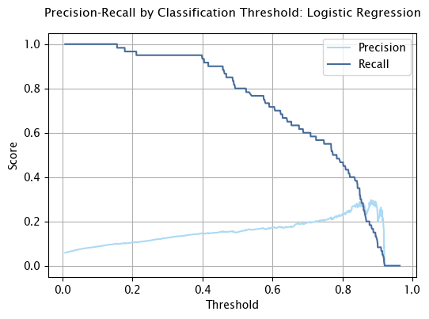

```python
y_pred_proba = logreg_model.predict_proba(X_test_prep_df)

prob_positive_log = y_pred_proba[:, 1]

precision, recall, thresholds = precision_recall_curve(y_test, prob_positive_log)

plt.figure(figsize=(6, 4))
plt.plot(thresholds, precision[:-1], label="Precision", color=custom_palette[0])
plt.plot(thresholds, recall[:-1], label="Recall", color=custom_palette[1])
plt.xlabel("Threshold")
plt.ylabel("Score")
plt.title("Precision-Recall by Classification Threshold: Logistic Regression")
plt.legend()
plt.grid(True)
plt.show()
```

```python
new_threshold = 0.52

y_pred_adj_log = (prob_positive_log >= new_threshold).astype(int)

print("Classification Report for Logistic Regression with Updated Threshold:")
print(classification_report(y_test, y_pred_adj_log))
```

```
Classification Report for Logistic Regression with Updated Threshold:
              precision    recall  f1-score   support

           0       0.98      0.74      0.84       962
           1       0.16      0.80      0.27        60

    accuracy                           0.74      1022
   macro avg       0.57      0.77      0.55      1022
weighted avg       0.93      0.74      0.81      1022
```

Keeping the recall for class 1 (stroke) the same, threshold was updated for the Logistic Regression model, which resulted in an improvement in recall for class 0 (no stroke). For class 1, precision increased marginally from 0.15 to 0.16.

Overall, the updated threshold led to a slight improvement in accuracy, from 0.72 to 0.74, and a modest improvement in the F1-score for both classes.

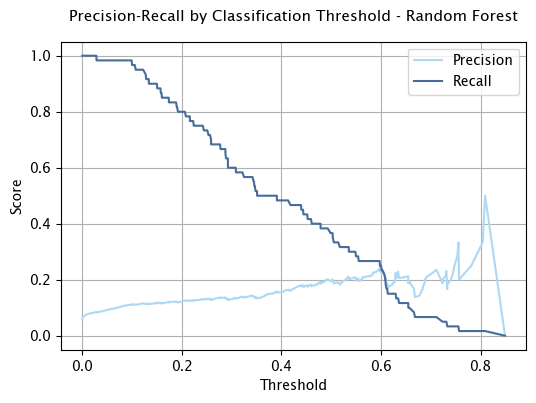

```python
y_pred_proba = rf_model.predict_proba(X_test_prep_df)

prob_positive_rf = y_pred_proba[:, 1]

precision, recall, thresholds = precision_recall_curve(y_test, prob_positive_rf)

plt.figure(figsize=(6, 4))
plt.plot(thresholds, precision[:-1], label="Precision", color=custom_palette[0])
plt.plot(thresholds, recall[:-1], label="Recall", color=custom_palette[1])
plt.xlabel("Threshold")
plt.ylabel("Score")
plt.title("Precision-Recall by Classification Threshold - Random Forest")
plt.legend()
plt.grid(True)
plt.show()
```

```python
new_threshold = 0.3

y_pred_adj_rf = (prob_positive_rf >= new_threshold).astype(int)

print("Classification Report for Random Forest with Updated Threshold:")
print(classification_report(y_test, y_pred_adj_rf))
```

```
Classification Report for Random Forest with Updated Threshold:
              precision    recall  f1-score   support

           0       0.97      0.75      0.85       962
           1       0.13      0.60      0.21        60

    accuracy                           0.74      1022
   macro avg       0.55      0.68      0.53      1022
weighted avg       0.92      0.74      0.81      1022
```

The accuracy of both models were made the same. The Random Forest model with the updated threshold showed considerable changes in precision and recall for both classes.

For class 0 (no stroke), precision increased slightly, while recall decreased substantially. For class 1 (stroke), precision decreased from 0.20 to 0.13, while recall increased notably from 0.37 to 0.60, suggesting a higher proportion of true positives were correctly identified.

##### Confusion Matrix

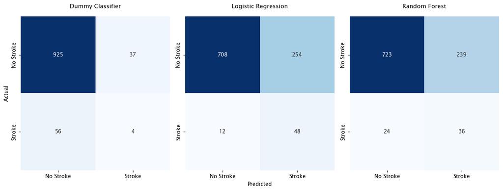

```python
conf_matrix_dummy = confusion_matrix(y_test, y_pred_dummy)
conf_matrix_logreg = confusion_matrix(y_test, y_pred_adj_log)
conf_matrix_rf = confusion_matrix(y_test, y_pred_adj_rf)

fig, axes = plt.subplots(1, 3, figsize=(13, 5))
class_labels = ["No Stroke", "Stroke"]

sns.heatmap(
    conf_matrix_dummy,
    annot=True,
    cmap="Blues",
    fmt="d",
    ax=axes[0],
    cbar=False,
    xticklabels=class_labels,
    yticklabels=class_labels,
)
axes[0].set_title("Dummy Classifier")
axes[0].set_xlabel("")
axes[0].set_ylabel("Actual")

sns.heatmap(
    conf_matrix_logreg,
    annot=True,
    cmap="Blues",
    fmt="d",
    ax=axes[1],
    cbar=False,
    xticklabels=class_labels,
    yticklabels=class_labels,
)
axes[1].set_title("Logistic Regression")
axes[1].set_xlabel("Predicted")
axes[1].set_ylabel("")

sns.heatmap(
    conf_matrix_rf,
    annot=True,
    cmap="Blues",
    fmt="d",
    ax=axes[2],
    cbar=False,
    xticklabels=class_labels,
    yticklabels=class_labels,
)
axes[2].set_title("Random Forest")
axes[2].set_xlabel("")
axes[2].set_ylabel("")

plt.tight_layout()
plt.show()
```

Both Logistic Regression and Random Forest perform better, with Random Forest slightly outperforming Logistic Regression in terms of false positives.

However, Logistic Regression has twice less of false negatives compared to Random Forest. Since this is a priority, it is chosen as the best model.

```python
dump(logreg_model, 'logreg_model.joblib')
```

```
['logreg_model.joblib']
```

The model is deployed [here](https://stroke-b5jk6u8tb2cpljafikfwbd.streamlit.app/).

## Summary and Recommendations

### Summary of the Findings

**Exploratory Data Analysis**

- The dataset contains information on more than 5000 individuals, including demographic details, health conditions, and lifestyle factors. Key features include age, gender, hypertension, heart disease, BMI, and smoking status.
- The dataset exhibits class imbalance, with a vast majority of individuals not experiencing a stroke.
- Correlation analysis showed that variables such as age, hypertension, and heart disease show significant correlations with stroke risk, while others like gender and residence type have weaker relationships.

**Statistical Inference**

- The first hypothesis tested for associations between categorical independent variables and the dependent variable. Variables such as hypertension, heart disease, and ever-married status exhibited highly significant associations with stroke occurrence. Work type and smoking status also displayed significant associations with strokes, although with moderate effect sizes.
- The second hypothesis explored differences in age distribution between individuals who have had a stroke and those who have not. Strong evidence (p-value < 0.05) suggests that a significant difference exists.

### Recommendations for Further Analysis

To gain deeper insights and enhance the analysis, the following steps could be considered:

- Explore Feature Engineering: Delve into feature engineering techniques to generate new variables or modify existing ones, potentially capturing more nuanced patterns and enhancing model performance.
- Collect More Data: Expand the dataset by incorporating additional variables related to lifestyle, medical history, or environmental factors. Increasing the temporal scope of the analysis could also provide valuable insights into long-term stroke prediction trends.
- Cluster Analysis: Utilize clustering algorithms to segment individuals based on their demographic, health, and lifestyle attributes. This approach could uncover distinct patterns within the dataset, facilitating targeted interventions and personalized risk assessment strategies.